# Assignment 1 Functional Data Analysis

Arturo Prieto Tirado

27/4/2021

# Exercise 2

The object gait is an array of size 20x39x2 containing the hip and knee angle in degrees through a 20 point movement cycle for 39 boys. Carry out the following tasks and write a report summarizing your work:

- 1. Make a plot of the hip angles for the first three boys using points and explain the main characteristics of the three hip angles.

The following plot shows the hip angle for the first three boys in black, red and green respectively for the first, second and third boy.

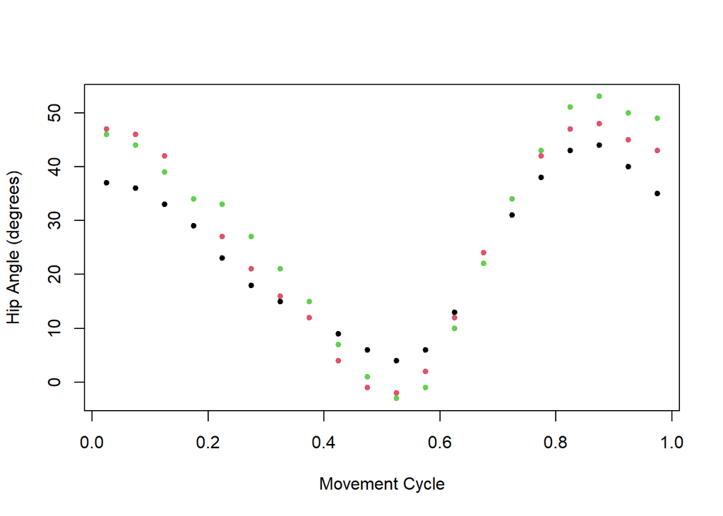

It can be seen that the general shape is similar for all of them, high angles at the beggining and end of the cycle and low angles in the middle, which suggest that there is a function governing hip angle. There are however individual differences since their amplitudes differ. Boy 1 has the smallest mobility range while Boy 3 has the greatest. The minimum value is -3 degrees and the maximum, 53 degrees.

- 2. Make a plot of all the hip angles using lines and explain their main characteristics.

We simply interpolate the points to build the lines

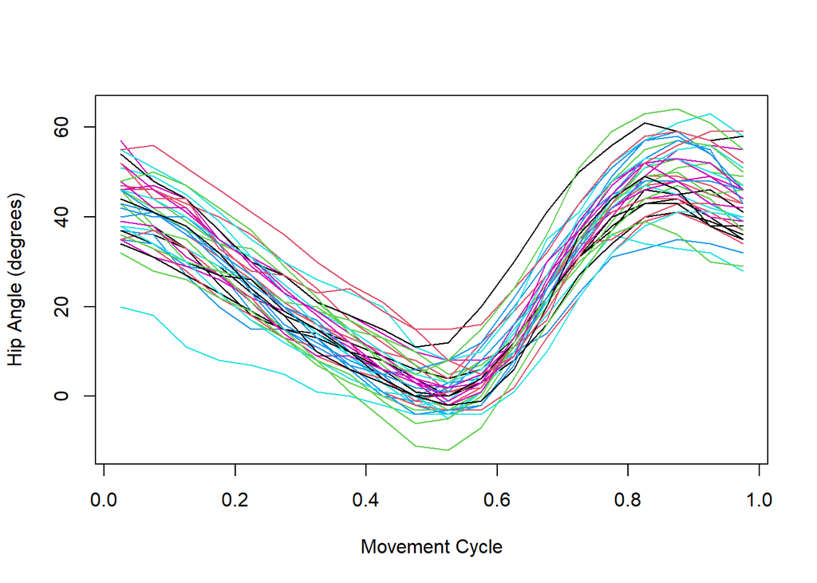

It can be seen that most of the children follow the same shape as the analysis done only for the three first boys, high angles at the beggining and end of the cycle and low angles in the middle. However, some of them follow curves far away from the group, with the possibility of being outliers. Also, the curves are obviously not smooth since we are just joining lines so the next step is to smooth them.

- 3. Smooth the hip angles corresponding to the first boy with OLS and penalized smoothing with a basis function system of your (appropriate) choice. Describe all the steps taken in your analysis with explanations and appropriate graphs.

Now we want to smooth the results just for the first boy. The way one smooths is by doing a basis expansion. I will use the Fourier basis since the data represent a cycle so they are expected to be periodic. Knowing the basis functions, one can just fit them appropriately to the data, that is, find the coefficients that build the best linear combination of the basis. However, it is first necessary to know the number $K$ of basis functions we want to use, because there are an infinite number of them. In order to do this, Cross Validation can be used to find $K$ minimizing the sum of squares. In order to reduce computational costs, Generalized Cross Validation (GCV) is used. The problem with this method is that it tends to select a very high number of basis functions, thus basically interpolating the data and creating very rough (not smoothed) curves. The approach that solves this is penalized smoothing. This method penalizes overfitting (associated with high values of $K$) by looking at the total curvature of the curve since the more complicated the curve, usually the more curvature, adding a penalization term with a factor of lambda, that one needs to optimize as well.

The goal here is to smooth the hip angle in the $39$ boys with **Fourier basis**. Initially, we focus first in smoothing the first boy in the data set. To see the effect of the value of $K$ in the curve estimate, we consider four different number of basis functions, $K=3$, $5$, $7$ and $9$. Remember that the number of Fourier basis functions should be an odd number and it has to be smaller than the number of points per boy, so 20. The closer to 20, the more overfitting.

For that, the first step is to **create the four Fourier basis systems** using the `fda` package. This is done using the function `create.fourier.basis`. The observation interval is $[0,1]$, with the extremes being the two points corresponding to a full period (cycle) that determine the periodicity of the function.

The second step is to **smooth the hip angle for the first boy with OLS** and the four Fourier basis systems. This is done using the function `smooth.basis`. Here, the observation points are $0.025$ to $0.975$, corresponding to each movement position.

Next, we see the four fittings. For that, we plot the observed points and the corresponding smoothings with the four Fourier basis. Clearly, **the larger the number of Fourier basis, the more overfitted is the data**. In other words, the more basis functions the less smooth are the functions obtained.

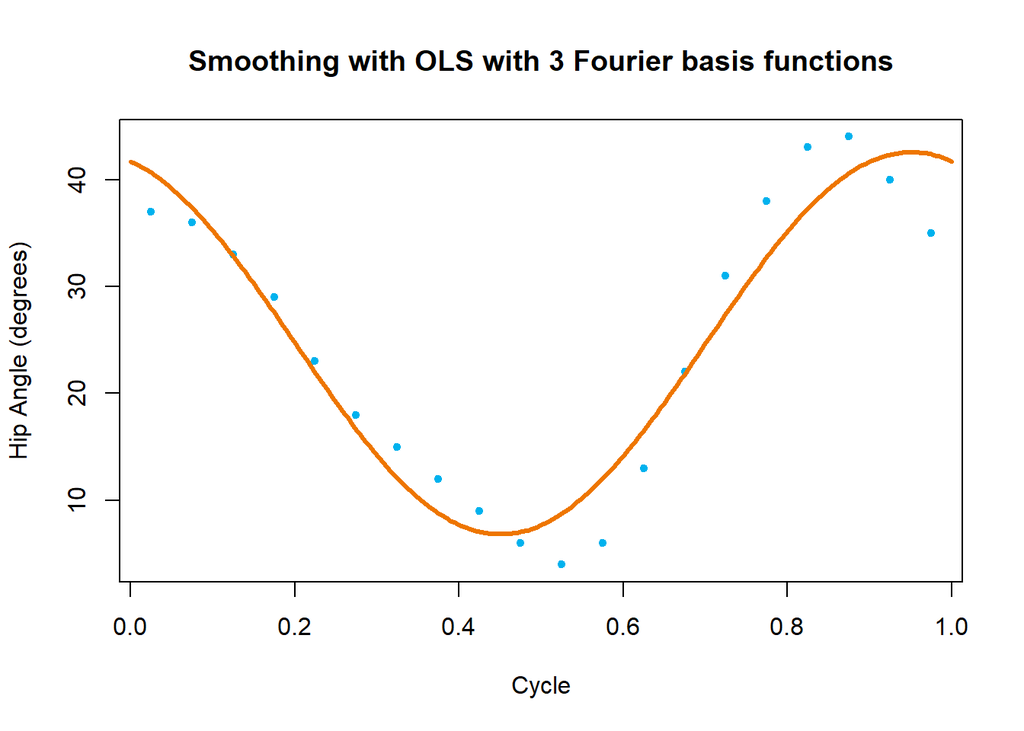

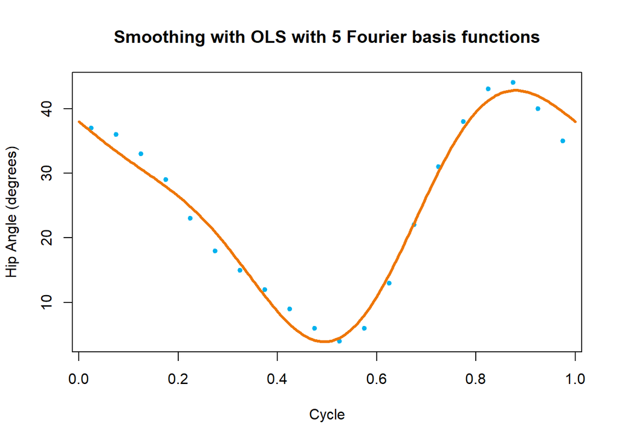

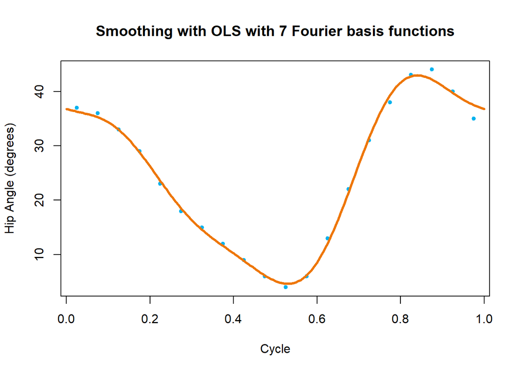

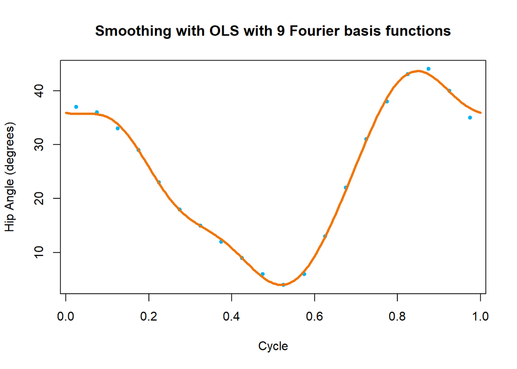

Additionally, we plot the four sets of residuals after the smoothings. Looking at the residuals can be helpful to see whether there are fitting problems. It is clear that with only 3 basis functions we are missing something in the fit, since the residuals have a clear pattern. This pattern diminishes once we add some more basis.

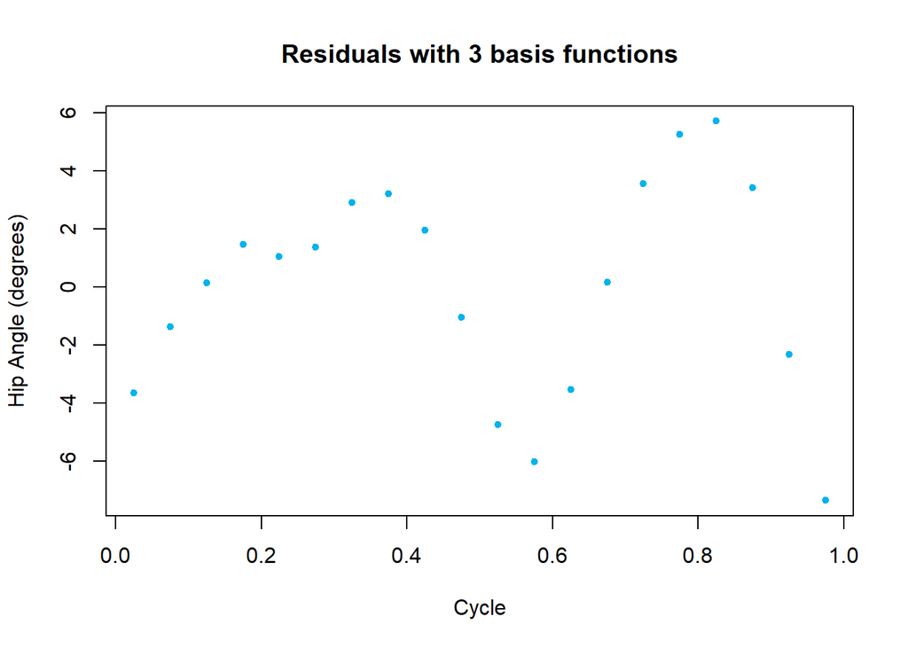

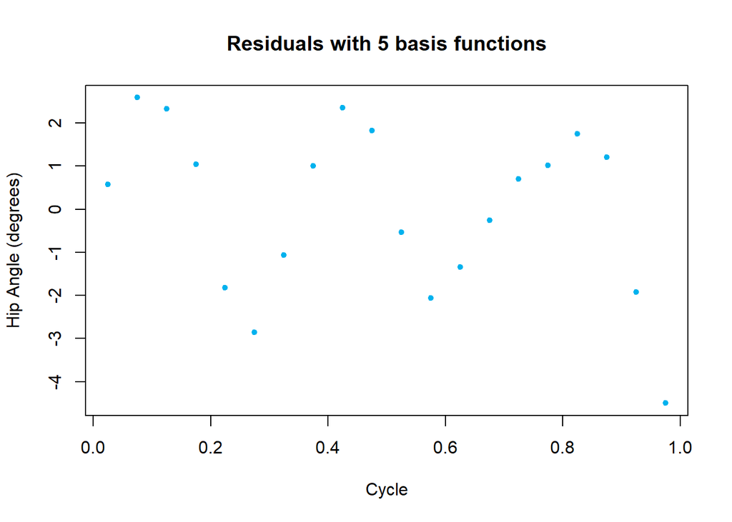

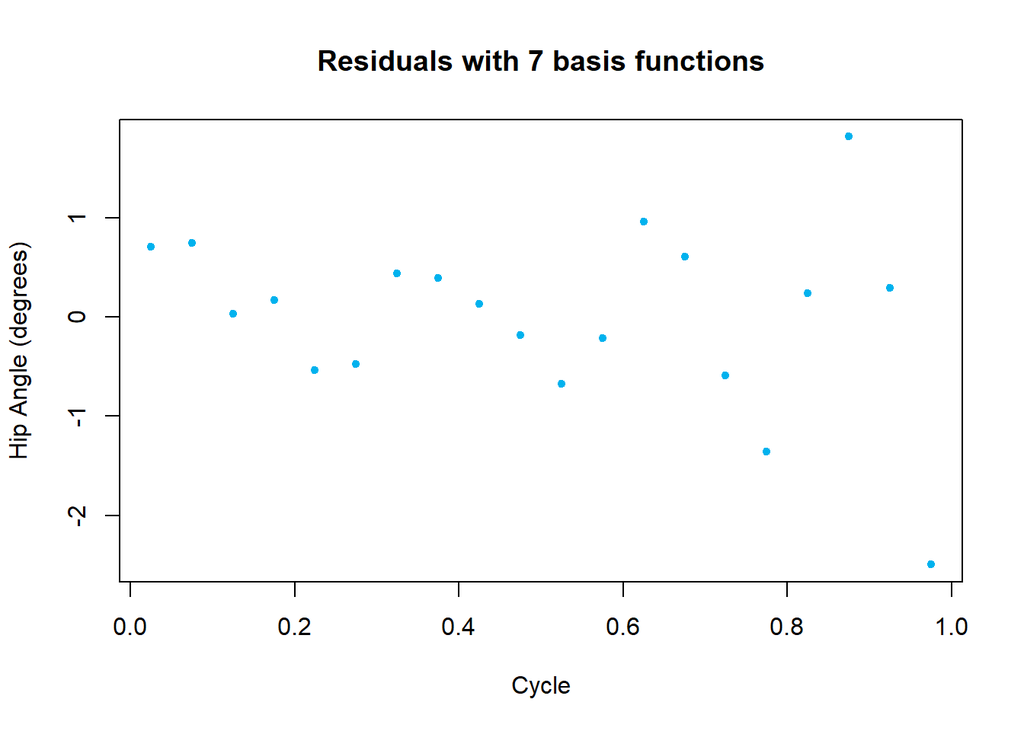

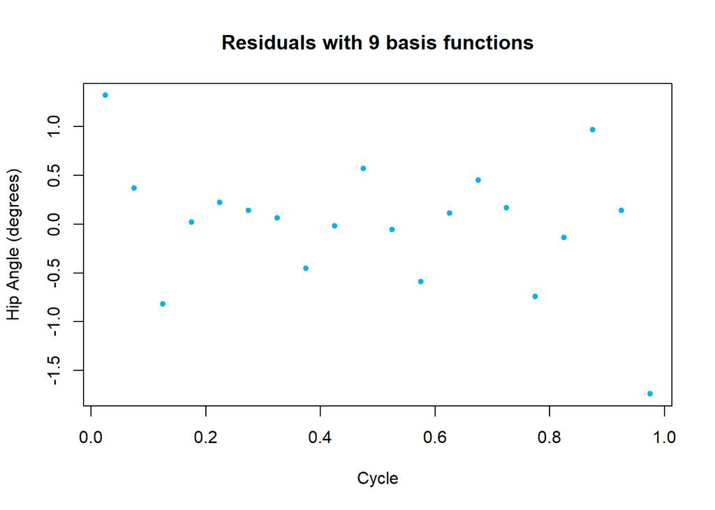

Now, we focus on the selection of $K$. For the previous fittings, it is easy to check that for the first boy **the larger K, the smaller the GCV**.

Now, let’s compute the value of the GCV criterion for a large selection of values of $k$, all odd from $3$ to $20$, and we will see which is the behavior of the GCV criterion for the candidate values of $k$.

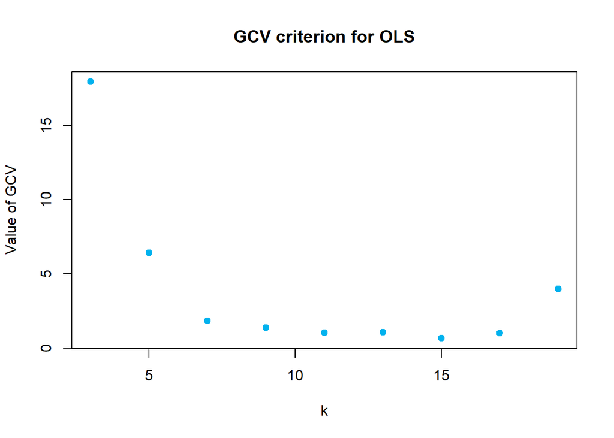

The plot shows the values of the GCV criterion decreases when $k$ increases, as expected. Thus, the GCV method will select a number of Fourier basis functions very large that leads to rough curves, from 7 basis functions in advance there is small improvement and overfitting. This is the main motivation of using smoothing with roughness penalties, which will be studied afterwards.

It can also be seen that it increases for very large $k$ since we only have 20 points, so $k=20$ or close to 20 is heavily overfitted, which is not optimal when generalizing to a new sample, which CV takes more or less into account.

Since GCV tends to select high values of $k$, in order to avoid overfitting, one can use **penalized smoothing**. Now, we attempt to smooth the hip angle of the first boy with this procedure . For that, we proceed to select an appropriate value of the penalization parameter $\lambda$. We first consider a large amount of very distant possible values of $\lambda$ and compute the value of the GCV criterion. For simplicity, we focus on the Fourier basis with $K=7$ basis functions.

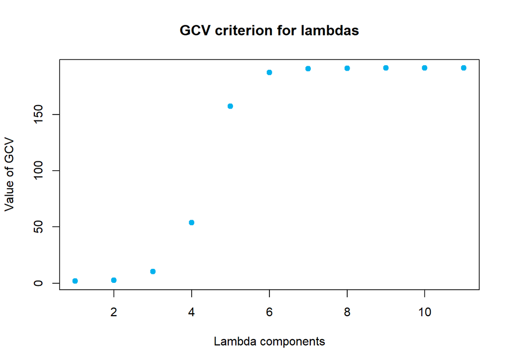

The optimal is of order $10^{-5}$. Then, we repeat the same scheme but taking several possible values of $\lambda$ between $10^{-6}$ and $10^{-5}$. In this case, the optimal value of $\lambda$ is $7\cdot10^{-6}$.

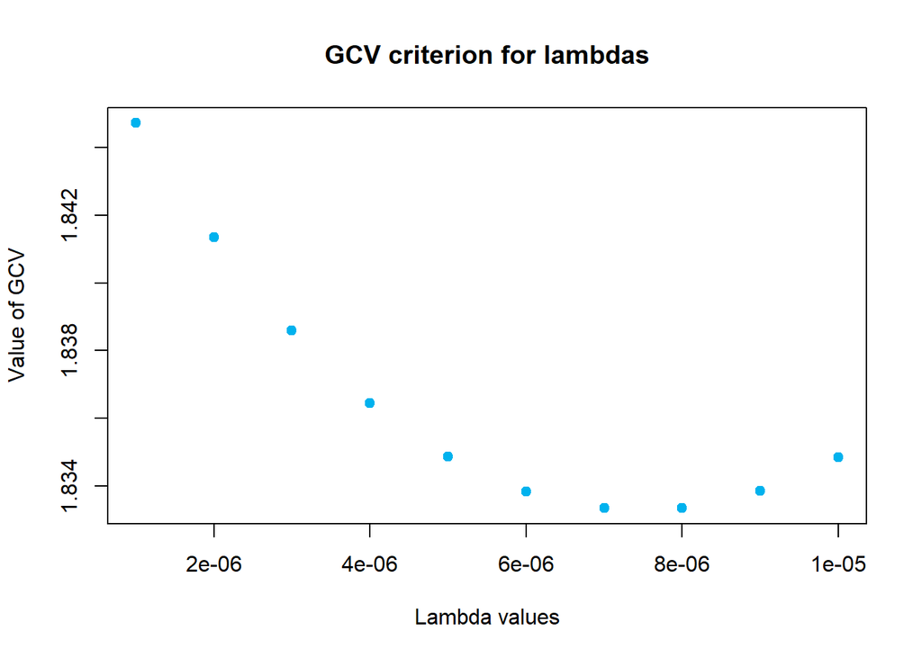

Once $\lambda$ has been selected, we can see the final fitting. The result is slightly smoother than the original fitting with $7$ Fourier basis functions. If we want more smoothing, we can increase the value of $\lambda$ or reduce the number of Fourier basis.

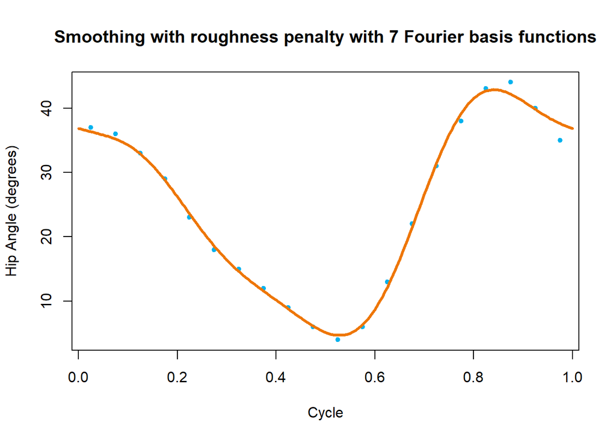

- 4. Smooth all the hip angles with OLS and penalized smoothing with a basis function system of your (appropriate) choice. Describe all the steps taken in your analysis with explanations and appropriate graphs.

Note that we have just smoothed a single boy. The way to proceed would be to repeat this scheme for all the boys where the value of the GCV for each value of $\lambda$ is the sum of the GCV for the 39 children. As before, the idea is to look for an appropriate value of $\lambda$ in the interval $[10^{-6},2\cdot10^{-5}]$. The optimal value in this case is to take $\lambda=1.4\cdot10^{-5}$.

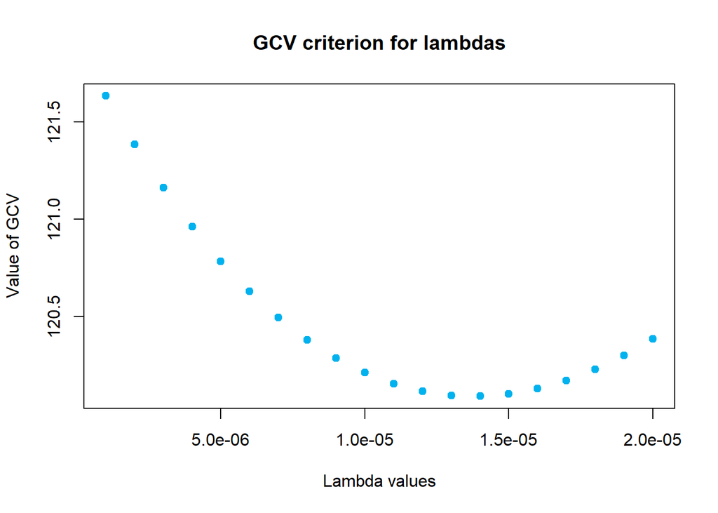

Then, we proceed to make the fit with such value of $\lambda=1.4\cdot10^{-5}$ for the $39$ children.

```
## [1] "done"
```

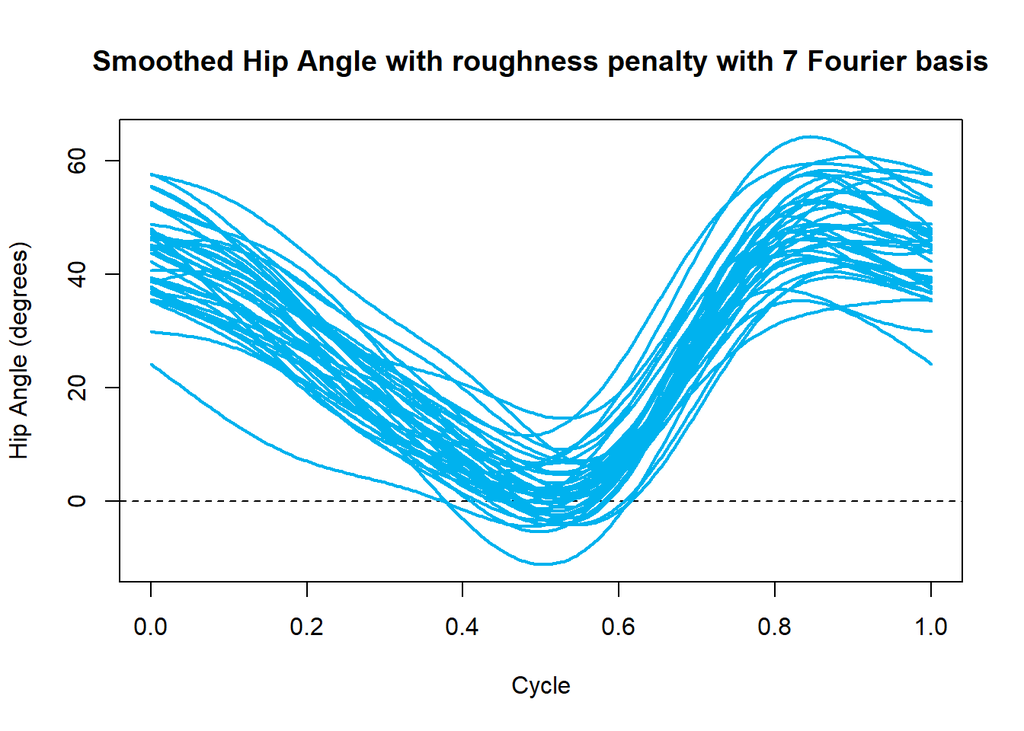

- 5. Obtain conclusions on the data set based on the analyses performed.

In conclusion, the methodology used has shown that the hip angle throughout the movement cycle can be understood as a random function whom each of its realizations represents the function governing each boy. This functions have been obtained by fitting periodic basis functions, Fourier functions, to each set of points of each boy, respecting the periodicity of the original data. This fitting has been improved by using penalized smoothing to avoid overfitting. In this way, the final curves obtained are very smooth and they all follow the same trend, high values at the beginning and end of the cycle and low values in the middle of it. With respect to the distribution of the functions, the majority of them are very close to each other but there are also some of them that are clearly away from the group, being potential outliers.

# Exercise 4

A few theoretical exercises about square integrable functions:

- 1. Prove the triangle inequality using the Cauchy-Schwarz inequality.

Let’s just start with the Triangle inequality
$$\|f+g\| \leq\|f\|+\|g\|$$
where $f, g \in L^{2}[a, b]$ and square it

$$\|f+g\|^2 \leq(\|f\|+\|g\|)^2$$

Now expand the result
$$\|f\|^2+\|g\|^2+2|\langle f,g\rangle| \leq \|f\|^2+\|g\|^2 +2\|f\|\|g\|$$

Simplifying, one gets
$$|\langle f, g\rangle| \leq\|f\|\|g\|$$
which is precisely the Cauchy-Schwarz inequality. Since the Cauchy-Schwarz inequality is true, it follows that the Triangle inequality is also true.

- 2. Prove the fourth line of slide 22.

We want to prove that if $f,g \in L^2[a,b]$ then for $c_1, c_2 \in \mathbb{R}$ it holds that $c_1f+c_2g \in L^2[a,b]$. The definition of a function being square integrable is that
$$f \in L^2[a,b] \iff \int_a^b f^2(t)dt<\infty$$
We would like to check whether $c_1f+c_2g \in L^2[a,b]$ which is equivalent to check that
$$\int_a^b (c_1f(t)+c_2g(t))^2dt=c_1^2\int_a^bf(t)^2dt+c_2^2\int_a^bg(t)^2dt+2c_1c_2\int_a^bf(t)g(t)dt\stackrel{?}{\leq}\infty$$

Since by hypothesis $f,g \in L^2[a,b]$, the two first integrals are bounded so the only thing left to check is
$$\int_a^bf(t)g(t)dt\stackrel{?}{\leq}\infty$$

Remember that $\int_a^bf(t)g(t)dt=\langle f,g\rangle$ and therefore using the Cauchy Schwarz inequality we have that
$$\int_a^bf(t)g(t)dt\leq \|f\|\|g\| \leq\infty \text{ since } f,g\in L^2[a.b]$$

Therefore

$$\int_a^b (c_1f(t)+c_2g(t))^2dt\leq \infty$$
which means that $c_1f+c_2g \in L^2[a,b]$, as we wanted to prove.

- 3. Prove the fourth line of slide 23.

We want to prove that if $e_1, e_2,..., \in L^2[a,b]$ are an orthonormal basis then $c_k=\langle f, e_k\rangle$. In order to prove this recall that any function $f \in L^2[a,b]$ admits a unique expansion as $f=\sum_k^\infty c_k e_k$ and that an orthonormal basis implies that $\langle e_k, e_l\rangle=0$ for $k\neq l$.

Let’s then expand $\langle f, e_k \rangle$ as

$$\langle f, e_k \rangle=\langle \sum_l^\infty c_le_l, e_k\rangle$$

Use the fact that the inner product has the linearity property $\langle x+y,w \rangle=\langle x,w \rangle+\langle y, w\rangle$ to take out the sumation and use that the basis is orthonormal to find the desired result
$$\langle f, e_k \rangle=\sum_l^\infty\langle c_le_l, e_k\rangle=c_k$$

- 4. Prove the Parceval’s inequality.

We want to prove that
$$\|f\|^2=\sum_k^\infty c_k^2$$

Since $f=\sum_k^\infty c_k e_k$ it is clear that

$$\|f\|^2=\langle f, f\rangle=\langle \sum_k^\infty c_ke_k, \sum_l^\infty c_le_l\rangle$$

Using the linearity property of the inner product and the orthonormality of the basis yields the Parceval’s inequality

$$\|f\|^2=\sum_k^\infty \sum_l^\infty\langle c_ke_k, c_le_l\rangle=\sum_k^\infty c_k^2$$